# Bay wheels Data exploration

## Preliminary Wrangling

[Bay wheels](https://www.lyft.com/bikes/bay-wheels) is a regional public bicycle sharing system in California's San Francisco Bay Area. It is operated by Motivate in a partnership with the Metropolitan Transportation Commission and the Bay Area Air Quality Management District.Bay Wheels is the first regional and large-scale bicycle sharing system deployed in California and on the West Coast of the United States . This documnet explores the data of Bay wheels for year 2019. [The dataset](https://www.lyft.com/bikes/bay-wheels/system-data) used for the analysis is the marge of Bay Wheels trip history data for each month in 2019 starting from january until December.

```python
# import all packages and set plots to be embedded inline
import numpy as np
import pandas as pd
import matplotlib.pyplot as plt
import seaborn as sb
import os


%matplotlib inline
```

## Gathering Data

```python
# load monthes datasets and merge them into one pandas data frame
monthes_frames = []
monthes_frames = [pd.read_csv('20190'+str(i+1)+'.csv') if i < 9 else pd.read_csv('2019'+str(i+1)+'.csv') for i in range(12)]
```

```python
Baywheel_19 = pd.concat(monthes_frames,ignore_index=True)
Baywheel_19.head()
```

|  | duration_sec | start_time | end_time | start_station_id | start_station_name | start_station_latitude | start_station_longitude | end_station_id | end_station_name | end_station_latitude | end_station_longitude | bike_id | user_type | bike_share_for_all_trip | rental_access_method |
| --- | --- | --- | --- | --- | --- | --- | --- | --- | --- | --- | --- | --- | --- | --- | --- |
| 0 | 80825 | 2019-01-31 17:57:44.6130 | 2019-02-01 16:24:49.8640 | 229.0 | Foothill Blvd at 42nd Ave | 37.775745 | -122.213037 | 196.0 | Grand Ave at Perkins St | 37.808894 | -122.256460 | 4861 | Subscriber | No | NaN |
| 1 | 65900 | 2019-01-31 20:58:33.8860 | 2019-02-01 15:16:54.1730 | 4.0 | Cyril Magnin St at Ellis St | 37.785881 | -122.408915 | 134.0 | Valencia St at 24th St | 37.752428 | -122.420628 | 5506 | Subscriber | No | NaN |
| 2 | 62633 | 2019-01-31 18:06:52.9240 | 2019-02-01 11:30:46.5300 | 245.0 | Downtown Berkeley BART | 37.870139 | -122.268422 | 157.0 | 65th St at Hollis St | 37.846784 | -122.291376 | 2717 | Customer | No | NaN |
| 3 | 44680 | 2019-01-31 19:46:09.7190 | 2019-02-01 08:10:50.3180 | 85.0 | Church St at Duboce Ave | 37.770083 | -122.429156 | 53.0 | Grove St at Divisadero | 37.775946 | -122.437777 | 4557 | Customer | No | NaN |
| 4 | 60709 | 2019-01-31 14:19:01.5410 | 2019-02-01 07:10:51.0650 | 16.0 | Steuart St at Market St | 37.794130 | -122.394430 | 28.0 | The Embarcadero at Bryant St | 37.787168 | -122.388098 | 2100 | Customer | No | NaN |

## Assessing Data

```python
Baywheel_19.info()
```

```
<class 'pandas.core.frame.DataFrame'>
RangeIndex: 2506983 entries, 0 to 2506982
Data columns (total 15 columns):
 #   Column                   Dtype
---  ------                   -----
 0   duration_sec             int64
 1   start_time               object
 2   end_time                 object
 3   start_station_id         float64
 4   start_station_name       object
 5   start_station_latitude   float64
 6   start_station_longitude  float64
 7   end_station_id           float64
 8   end_station_name         object
 9   end_station_latitude     float64
 10  end_station_longitude    float64
 11  bike_id                  int64
 12  user_type                object
 13  bike_share_for_all_trip  object
 14  rental_access_method     object
dtypes: float64(6), int64(2), object(7)
memory usage: 286.9+ MB
```

```python
Baywheel_19.shape
```

```
(2506983, 15)
```

```python
Baywheel_19.describe()
```

|  | duration_sec | start_station_id | start_station_latitude | start_station_longitude | end_station_id | end_station_latitude | end_station_longitude | bike_id |
| --- | --- | --- | --- | --- | --- | --- | --- | --- |
| count | 2.506983e+06 | 2.426249e+06 | 2.506983e+06 | 2.506983e+06 | 2.424081e+06 | 2.506983e+06 | 2.506983e+06 | 2.506983e+06 |
| mean | 8.076483e+02 | 1.465047e+02 | 3.776506e+01 | -1.223499e+02 | 1.427044e+02 | 3.776422e+01 | -1.223459e+02 | 2.789833e+04 |
| std | 1.974714e+03 | 1.223171e+02 | 1.363698e-01 | 3.089648e-01 | 1.214296e+02 | 2.392885e-01 | 7.080417e-01 | 1.146067e+05 |
| min | 6.000000e+01 | 3.000000e+00 | 0.000000e+00 | -1.225143e+02 | 3.000000e+00 | 0.000000e+00 | -1.225143e+02 | 4.000000e+00 |
| 25% | 3.590000e+02 | 4.700000e+01 | 3.776931e+01 | -1.224130e+02 | 4.300000e+01 | 3.777003e+01 | -1.224117e+02 | 1.952000e+03 |
| 50% | 5.710000e+02 | 1.050000e+02 | 3.778053e+01 | -1.223983e+02 | 1.010000e+02 | 3.778076e+01 | -1.223981e+02 | 4.420000e+03 |
| 75% | 8.870000e+02 | 2.430000e+02 | 3.779539e+01 | -1.222914e+02 | 2.390000e+02 | 3.779587e+01 | -1.222934e+02 | 9.682000e+03 |
| max | 9.121100e+05 | 4.980000e+02 | 4.551000e+01 | 0.000000e+00 | 4.980000e+02 | 4.551000e+01 | 0.000000e+00 | 9.999410e+05 |

```python
Baywheel_19.isnull().sum()
```

```
duration_sec                     0
start_time                       0
end_time                         0
start_station_id             80734
start_station_name           80133
start_station_latitude           0
start_station_longitude          0
end_station_id               82902
end_station_name             82350
end_station_latitude             0
end_station_longitude            0
bike_id                          0
user_type                        0
bike_share_for_all_trip     243259
rental_access_method       2386145
dtype: int64
```

```python
Baywheel_19.rental_access_method.value_counts()
```

```
app        108010
clipper     12828
Name: rental_access_method, dtype: int64
```

```python
Baywheel_19.bike_share_for_all_trip.value_counts()
```

```
No     2086152
Yes     177572
Name: bike_share_for_all_trip, dtype: int64
```

```python
Baywheel_19.start_station_name.value_counts()
```

```
Market St at 10th St                                         45058
Berry St at 4th St                                           42962
San Francisco Caltrain (Townsend St at 4th St)               40302
San Francisco Ferry Building (Harry Bridges Plaza)           39016
San Francisco Caltrain Station 2  (Townsend St at 4th St)    36576
                                                             ...
Prototype Lab                                                    4
Mercado Way at Sierra Rd                                         3
San Jose Depot                                                   3
Philly Demo                                                      2
SF Test Station                                                  1
Name: start_station_name, Length: 446, dtype: int64
```

```python
Baywheel_19.end_station_name.value_counts()
```

```
San Francisco Caltrain Station 2  (Townsend St at 4th St)    52146
San Francisco Caltrain (Townsend St at 4th St)               50943
San Francisco Ferry Building (Harry Bridges Plaza)           48180
Montgomery St BART Station (Market St at 2nd St)             47886
Market St at 10th St                                         44284
                                                             ...
Mercado Way at Sierra Rd                                         4
Howard workshop - Station in a Box                               4
San Jose Depot                                                   2
Philly Demo                                                      2
Emeryville Depot                                                 1
Name: end_station_name, Length: 446, dtype: int64
```

```python
Baywheel_19.user_type.unique()
```

```
array(['Subscriber', 'Customer'], dtype=object)
```

```python
Baywheel_19.start_station_name.unique()
```

[output not shown]

[output cut: 180 more lines]

```
       '5th Ave at Anza St', 'Columbia Ave at Bird Ave',
       'Ellis St at Pierce St', 'Evans Ave at Mendell St',
       'Turk Blvd at Stanyan St', 'Willow St at Blewett Ave',
       '19th St at William St', 'Prototype Lab',
       'Steiner St at California St', 'Folsom St at 7th St',
       'Powell St at Columbus Ave', "O'Farrell St at Masonic Ave",
       'Funston Ave at Fulton St', 'Funston Ave at Clement St',
       'Arguello Blvd at Edward St', '7th St at King St',
       '9th Ave at Geary Blvd', 'Greenwich St at Franklin St',
       '17th Ave at Geary Blvd', 'Webster St at Clay St',
       'Devine St at San Pedro St', 'Egbert Ave at Jennings St',
       'Philly Demo', '16th Depot Bike Fleet Station',
       'Frederick St at Arguello Blvd', 'St James St at 9th St',
       'Frida Kahlo Way at Cloud Cir', 'Mercado Way at Sierra Rd',
       'Park Ave at Laurel Grove Ln'], dtype=object)
```

```python
Baywheel_19[Baywheel_19.start_station_name ==""]
```

|  | duration_sec | start_time | end_time | start_station_id | start_station_name | start_station_latitude | start_station_longitude | end_station_id | end_station_name | end_station_latitude | end_station_longitude | bike_id | user_type | bike_share_for_all_trip | rental_access_method |
| --- | --- | --- | --- | --- | --- | --- | --- | --- | --- | --- | --- | --- | --- | --- | --- |

```python
Baywheel_19.end_station_name.unique()
```

[output not shown]

[output cut: 180 more lines]

```
       'Turk Blvd at Stanyan St', '22nd St at William St',
       '5th Ave at Anza St', 'Columbia Ave at Bird Ave',
       'Ellis St at Pierce St', '16th Depot Bike Fleet Station',
       'Evans Ave at Mendell St', 'Willow St at Blewett Ave',
       '19th St at William St', 'Prototype Lab', 'Folsom St at 7th St',
       'Steiner St at California St', "O'Farrell St at Masonic Ave",
       '17th Ave at Geary Blvd', '7th St at King St',
       'Powell St at Columbus Ave', '9th Ave at Geary Blvd',
       'Funston Ave at Clement St', 'Funston Ave at Fulton St',
       'Arguello Blvd at Edward St', 'Greenwich St at Franklin St',
       'Egbert Ave at Jennings St', 'Philly Demo',
       'Frederick St at Arguello Blvd', 'Frida Kahlo Way at Cloud Cir',
       'Webster St at Clay St', 'St James St at 9th St',
       'Devine St at San Pedro St', 'Park Ave at Laurel Grove Ln',
       'Mercado Way at Sierra Rd'], dtype=object)
```

```python
Baywheel_19[Baywheel_19.end_station_name ==""]
```

|  | duration_sec | start_time | end_time | start_station_id | start_station_name | start_station_latitude | start_station_longitude | end_station_id | end_station_name | end_station_latitude | end_station_longitude | bike_id | user_type | bike_share_for_all_trip | rental_access_method |
| --- | --- | --- | --- | --- | --- | --- | --- | --- | --- | --- | --- | --- | --- | --- | --- |

```python
Baywheel_19.start_station_id.unique()
```

[output not shown]

```python
Baywheel_19.to_csv('Baywheel_19.csv')
```

```python
Baywheel_19_clean = Baywheel_19.copy()
```

```python
Baywheel_19_clean.sort_values(by='start_time',inplace = True)
```

```python
Baywheel_19_clean.head()
```

|  | duration_sec | start_time | end_time | start_station_id | start_station_name | start_station_latitude | start_station_longitude | end_station_id | end_station_name | end_station_latitude | end_station_longitude | bike_id | user_type | bike_share_for_all_trip | rental_access_method |
| --- | --- | --- | --- | --- | --- | --- | --- | --- | --- | --- | --- | --- | --- | --- | --- |
| 192081 | 226 | 2019-01-01 00:07:10.5760 | 2019-01-01 00:10:57.1960 | 245.0 | Downtown Berkeley BART | 37.870139 | -122.268422 | 247.0 | Fulton St at Bancroft Way | 37.867789 | -122.265896 | 5117 | Customer | No | NaN |
| 192053 | 1767 | 2019-01-01 00:08:39.6590 | 2019-01-01 00:38:06.8480 | 16.0 | Steuart St at Market St | 37.794130 | -122.394430 | 115.0 | Jackson Playground | 37.765026 | -122.398773 | 1705 | Customer | No | NaN |
| 192080 | 182 | 2019-01-01 00:09:56.2110 | 2019-01-01 00:12:58.7480 | 269.0 | Telegraph Ave at Carleton St | 37.862320 | -122.258801 | 240.0 | Haste St at Telegraph Ave | 37.866043 | -122.258804 | 4621 | Subscriber | Yes | NaN |
| 192079 | 565 | 2019-01-01 00:11:03.4410 | 2019-01-01 00:20:29.2680 | 269.0 | Telegraph Ave at Carleton St | 37.862320 | -122.258801 | 243.0 | Bancroft Way at College Ave | 37.869360 | -122.254337 | 4783 | Subscriber | Yes | NaN |
| 192075 | 710 | 2019-01-01 00:14:48.3980 | 2019-01-01 00:26:38.4210 | 163.0 | Lake Merritt BART Station | 37.797320 | -122.265320 | 159.0 | 24th St at Market St | 37.816060 | -122.278244 | 4892 | Customer | No | NaN |

## Quality issues

It includes issues such as completeness, validity, Accuracy and consistency in data

- Fill missing values in start_station_name ,end_station_name , bike_share_for_all_trip , rental_access_method with None .
- Fill missing values in start_station_id , end_station_id with -1 .
- change start_station_id ,end_station_id from float to int.
- change start_time , end_time from string to date time.

## Tidiness¶

Tidy data is a standard way of mapping the meaning of a dataset to its structure. A dataset is messy or tidy depending on how rows, columns and tables are matched up with observations, variables and types. In tidy data:

- Each variable forms a column.
- Each observation forms a row.
- Each type of observational unit forms a table.

issues

- add a column for duration in minutes (duration_min)
- add a column for month name.
- add a column for day name.

# cleaning Data

### Quality issue #1.

### Define: Fill missing values in start_station_name , end_station_name , bike_share_for_all_trip , rental_access_method with None.

### code :

```python
null_columns = ['start_station_name','end_station_name','bike_share_for_all_trip','rental_access_method']
Baywheel_19_clean[null_columns] = Baywheel_19_clean[null_columns].fillna("None")
```

### Quality issue #2.

### Define: Fill missing values in start_station_id , end_station_id with -1.

### code :

```python
Baywheel_19_clean[['start_station_id','end_station_id']] = Baywheel_19_clean[['start_station_id','end_station_id']].fillna(-1)
```

```python
Baywheel_19_clean.isnull().sum()
```

```
duration_sec               0
start_time                 0
end_time                   0
start_station_id           0
start_station_name         0
start_station_latitude     0
start_station_longitude    0
end_station_id             0
end_station_name           0
end_station_latitude       0
end_station_longitude      0
bike_id                    0
user_type                  0
bike_share_for_all_trip    0
rental_access_method       0
dtype: int64
```

```python
Baywheel_19_clean.info()
```

```
<class 'pandas.core.frame.DataFrame'>
Int64Index: 2506983 entries, 192081 to 2492243
Data columns (total 15 columns):
 #   Column                   Dtype
---  ------                   -----
 0   duration_sec             int64
 1   start_time               object
 2   end_time                 object
 3   start_station_id         float64
 4   start_station_name       object
 5   start_station_latitude   float64
 6   start_station_longitude  float64
 7   end_station_id           float64
 8   end_station_name         object
 9   end_station_latitude     float64
 10  end_station_longitude    float64
 11  bike_id                  int64
 12  user_type                object
 13  bike_share_for_all_trip  object
 14  rental_access_method     object
dtypes: float64(6), int64(2), object(7)
memory usage: 306.0+ MB
```

### Quality issue #3.

### Define: change start_station_id ,end_station_id from float to int

### code :

```python
Baywheel_19_clean['start_station_id'] = Baywheel_19_clean['start_station_id'].astype(int)
Baywheel_19_clean['end_station_id'] = Baywheel_19_clean['end_station_id'].astype(int)
```

### Quality issue #4.

### Define: change start_time , end_time from string to date time

### code :

```python
Baywheel_19_clean['start_time'] = pd.to_datetime(Baywheel_19_clean['start_time'])
```

```python
Baywheel_19_clean['end_time'] = pd.to_datetime(Baywheel_19_clean['end_time'])
```

```python
Baywheel_19_clean.info()
```

```
<class 'pandas.core.frame.DataFrame'>
Int64Index: 2506983 entries, 192081 to 2492243
Data columns (total 15 columns):
 #   Column                   Dtype
---  ------                   -----
 0   duration_sec             int64
 1   start_time               datetime64[ns]
 2   end_time                 datetime64[ns]
 3   start_station_id         int32
 4   start_station_name       object
 5   start_station_latitude   float64
 6   start_station_longitude  float64
 7   end_station_id           int32
 8   end_station_name         object
 9   end_station_latitude     float64
 10  end_station_longitude    float64
 11  bike_id                  int64
 12  user_type                object
 13  bike_share_for_all_trip  object
 14  rental_access_method     object
dtypes: datetime64[ns](2), float64(4), int32(2), int64(2), object(5)
memory usage: 286.9+ MB
```

### Tidiness #1.

### Define: add a column for duration in minutes (duration_min).

### code :

```python
Baywheel_19_clean['duration_min'] = Baywheel_19_clean['duration_sec']/60
```

```python
Baywheel_19_clean.info()
```

```
<class 'pandas.core.frame.DataFrame'>
Int64Index: 2506983 entries, 192081 to 2492243
Data columns (total 16 columns):
 #   Column                   Dtype
---  ------                   -----
 0   duration_sec             int64
 1   start_time               datetime64[ns]
 2   end_time                 datetime64[ns]
 3   start_station_id         int32
 4   start_station_name       object
 5   start_station_latitude   float64
 6   start_station_longitude  float64
 7   end_station_id           int32
 8   end_station_name         object
 9   end_station_latitude     float64
 10  end_station_longitude    float64
 11  bike_id                  int64
 12  user_type                object
 13  bike_share_for_all_trip  object
 14  rental_access_method     object
 15  duration_min             float64
dtypes: datetime64[ns](2), float64(5), int32(2), int64(2), object(5)
memory usage: 306.0+ MB
```

```python
Baywheel_19_clean['duration_sec'].value_counts()
```

```
339      3298
370      3268
372      3251
353      3244
355      3242
         ...
39881       1
25558       1
7129        1
11231       1
25573       1
Name: duration_sec, Length: 15280, dtype: int64
```

### Tidiness #2.

### Define: add a column for month name.

### code :

```python
Baywheel_19_clean['month'] = Baywheel_19_clean['start_time'].apply(lambda time: time.strftime('%B'))
```

```python
Baywheel_19_clean.info()
```

```
<class 'pandas.core.frame.DataFrame'>
Int64Index: 2506983 entries, 192081 to 2492243
Data columns (total 17 columns):
 #   Column                   Dtype
---  ------                   -----
 0   duration_sec             int64
 1   start_time               datetime64[ns]
 2   end_time                 datetime64[ns]
 3   start_station_id         int32
 4   start_station_name       object
 5   start_station_latitude   float64
 6   start_station_longitude  float64
 7   end_station_id           int32
 8   end_station_name         object
 9   end_station_latitude     float64
 10  end_station_longitude    float64
 11  bike_id                  int64
 12  user_type                object
 13  bike_share_for_all_trip  object
 14  rental_access_method     object
 15  duration_min             float64
 16  month                    object
dtypes: datetime64[ns](2), float64(5), int32(2), int64(2), object(6)
memory usage: 325.2+ MB
```

```python
Baywheel_19_clean.month.value_counts()
```

```
July         258102
March        256299
October      239895
April        239111
September    217986
August       210563
January      192082
June         191772
November     185496
February     183412
May          182163
December     150102
Name: month, dtype: int64
```

### code :

```python
Baywheel_19_clean['day_name'] = Baywheel_19_clean['start_time'].apply(lambda time: time.strftime('%A'))
```

```python
Baywheel_19_clean['day_name'].value_counts()
```

```
Tuesday      427640
Thursday     424474
Wednesday    414448
Friday       397284
Monday       396463
Saturday     234370
Sunday       212304
Name: day_name, dtype: int64
```

```python
Baywheel_19_clean.info()
```

```
<class 'pandas.core.frame.DataFrame'>
Int64Index: 2506983 entries, 192081 to 2492243
Data columns (total 18 columns):
 #   Column                   Dtype
---  ------                   -----
 0   duration_sec             int64
 1   start_time               datetime64[ns]
 2   end_time                 datetime64[ns]
 3   start_station_id         int32
 4   start_station_name       object
 5   start_station_latitude   float64
 6   start_station_longitude  float64
 7   end_station_id           int32
 8   end_station_name         object
 9   end_station_latitude     float64
 10  end_station_longitude    float64
 11  bike_id                  int64
 12  user_type                object
 13  bike_share_for_all_trip  object
 14  rental_access_method     object
 15  duration_min             float64
 16  month                    object
 17  day_name                 object
dtypes: datetime64[ns](2), float64(5), int32(2), int64(2), object(7)
memory usage: 344.3+ MB
```

```python
Baywheel_19_clean.to_csv('Baywheel_19_clean.csv')
```

### What is/are the main feature(s) of interest in your dataset?

- how the trib duration affected by other feature such as rental_access_method , user_type , day of the week , month of the year
- which rental method is more usable ?
- which time that has the highest number of trips ?
- which stations that has more trips ? ### What features in the dataset do you think will help support your investigation into your feature(s) of interest?
- rental_access_method
- user_type
- start_time
- end_time
- start_station_name
- end_Station_name
- duration_sec

## Univariate Exploration

### The distribtion of trip duration

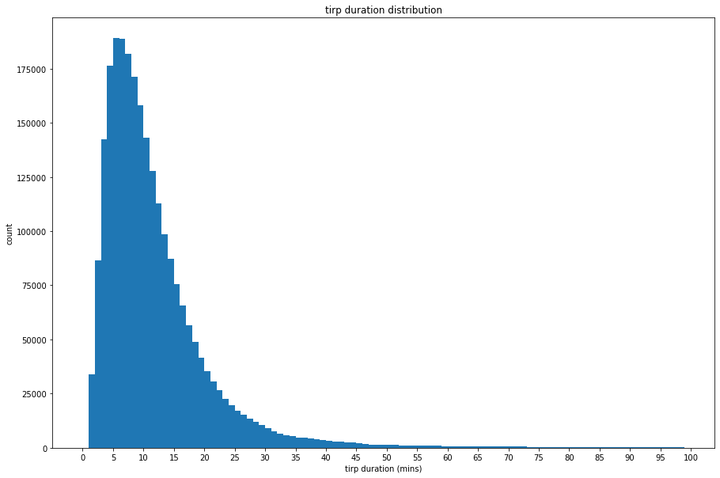

```python
bins = np.arange(0,100,1)
ticks = np.arange(0,105,5)
plt.figure(figsize = [15,10])
plt.hist(data = Baywheel_19_clean , x = 'duration_min', bins = bins)
plt.title("tirp duration distribution")
plt.xlabel('tirp duration (mins)')
plt.xticks(ticks)
plt.ylabel("count");
```

### Number of trips in each month of the year

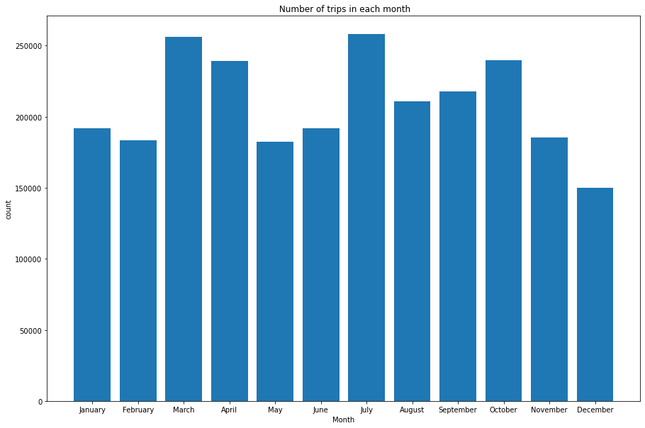

```python
plt.figure(figsize = [15,10])
monthes = ['January' , 'February', 'March','April','May','June' , 'July','August','September', 'October','November','December']
plt.bar(height = Baywheel_19_clean.month.value_counts().reindex(monthes), x = monthes)
plt.title(" Number of trips in each month")
plt.xlabel('Month')
plt.ylabel("count");
```

#### - july is the month with the highest number of trips followed by March .

#### - December is the month the lowest number of trips.

### Number of trips in each day of the week .

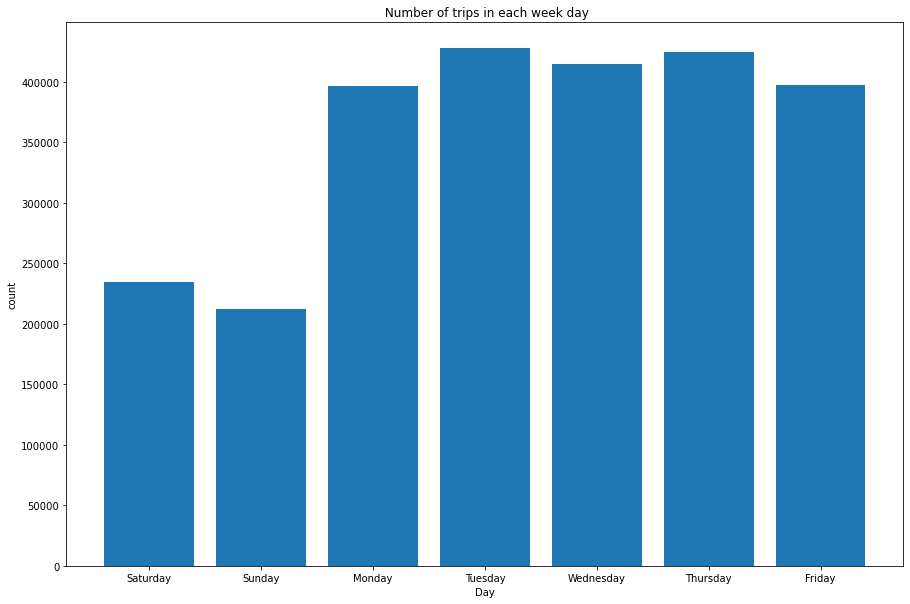

```python
plt.figure(figsize = [15,10])
days = ['Saturday' , 'Sunday', 'Monday','Tuesday','Wednesday','Thursday' , 'Friday']
plt.bar(height = Baywheel_19_clean.day_name.value_counts().reindex(days), x = days)
plt.title(" Number of trips in each week day")
plt.xlabel('Day')
plt.ylabel("count");
```

#### - Tuseday is the day with the highest number of trips followed by Thursday .

#### - Sunday is is the day with the lowest number of trips .

### Number of trips in each hour of the day .

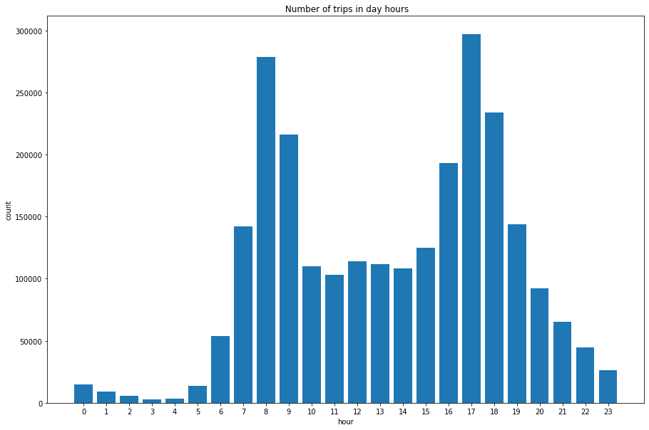

```python
plt.figure(figsize = [15,10])
x_tick_labels = np.arange(0,24,1)
x_tick_labels = x_tick_labels.astype(str)
plt.bar(height = Baywheel_19_clean.groupby(Baywheel_19_clean['start_time'].dt.hour)['start_time'].count(), x = x_tick_labels)
plt.title(" Number of trips in day hours")
plt.xlabel('hour')
plt.ylabel("count");
```

#### - Hour 17 in the day is the hour with the highest number of trips followed by hour 8 and hour 18 .

#### - Hour 3 in the day is the lowest number of trips followed by hour 4 and hour 2 .

### exploring which rental access method is more used

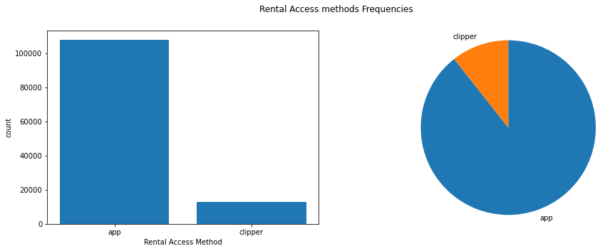

```python
plt.figure(figsize = [15,5])
plt.subplot(1,2,1)
rental_method = Baywheel_19_clean[Baywheel_19_clean['rental_access_method']!= "None"]["rental_access_method"].value_counts()
plt.bar(height = rental_method ,x = rental_method.index)
plt.xlabel('Rental Access Method')
plt.ylabel("count")
plt.subplot(1,2,2)
plt.pie(x= rental_method.values,labels= rental_method.index ,startangle = 90,counterclock= False)
plt.axis('square')
plt.suptitle("Rental Access methods Frequencies");
```

#### app is more likely to be used as a rental access method .

### explore user type feature

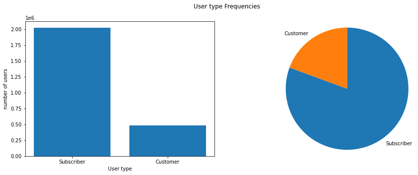

```python
plt.figure(figsize = [15,5])
plt.subplot(1,2,1)
user_type = Baywheel_19_clean["user_type"].value_counts()
plt.bar(height = user_type ,x = user_type.index)
plt.xlabel('User type')
plt.ylabel("number of users")
plt.subplot(1,2,2)
plt.pie(x= user_type.values,labels= user_type.index ,startangle = 90,counterclock= False)
plt.axis('square')
plt.suptitle("User type Frequencies");
```

#### It is clear that most of the users are subscribers

### Most and least used stations as start stations

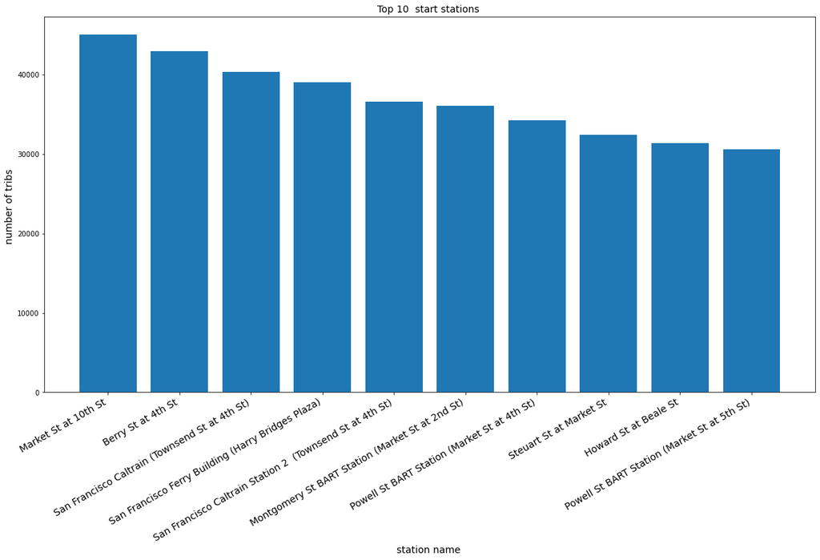

```python
plt.figure(figsize = [20,10])
top_start_station = Baywheel_19_clean[Baywheel_19_clean['start_station_id']!= -1]["start_station_name"].value_counts().head(10)
plt.bar(height = top_start_station ,x = top_start_station.index)
plt.xticks(rotation = 30,fontsize= 14 , ha='right')
plt.xlabel("station name ",fontsize= 14)
plt.ylabel("number of tribs ",fontsize= 14)
plt.title("Top 10  start stations ",fontsize= 14);
```

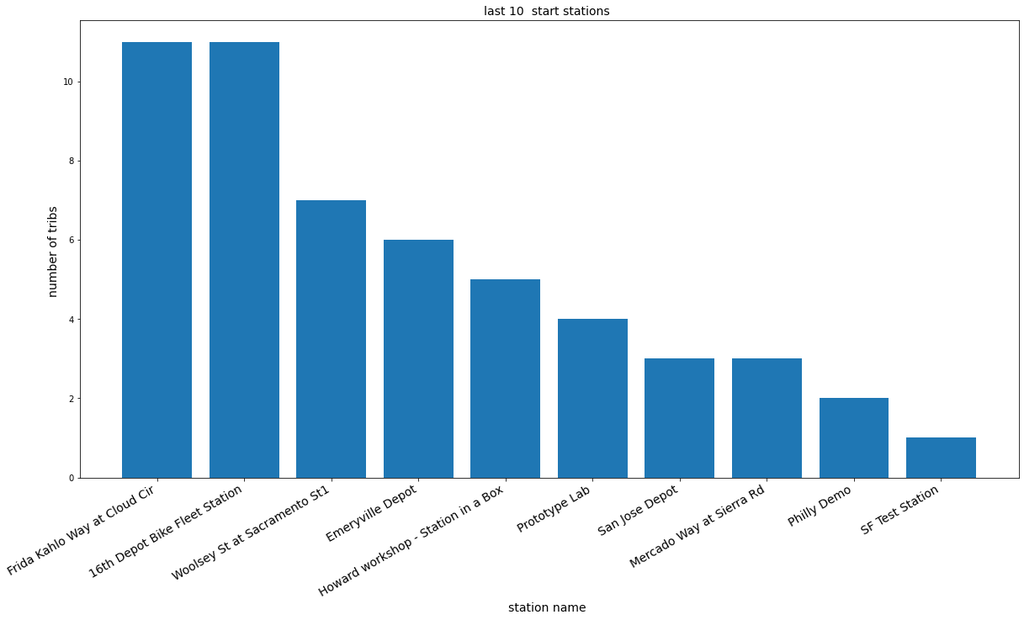

```python
plt.figure(figsize = [20,10])
last_start_station = Baywheel_19_clean[Baywheel_19_clean['start_station_id']!= -1]["start_station_name"].value_counts().tail(10)
plt.bar(height = last_start_station ,x = last_start_station.index)
plt.xticks(rotation = 30,fontsize= 14 , ha='right')
plt.xlabel("station name ",fontsize= 14)
plt.ylabel("number of tribs ",fontsize= 14)
plt.title("last 10  start stations ",fontsize= 14);
```

### Most and least used stations as end stations

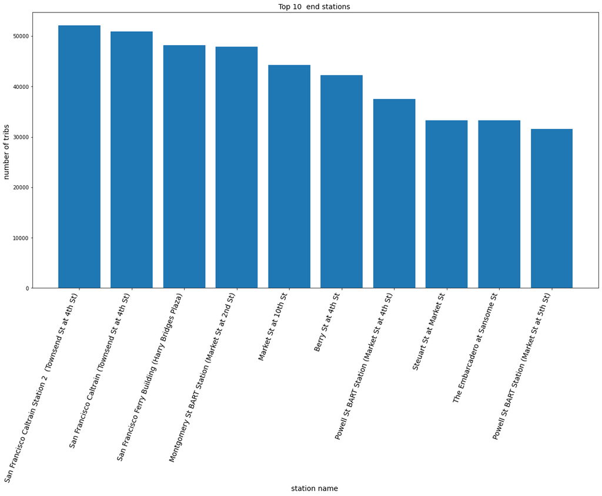

```python
plt.figure(figsize = [20,10])
end_station = Baywheel_19_clean[Baywheel_19_clean['end_station_id']!= -1]["end_station_name"].value_counts().head(10)
plt.bar(height = end_station ,x = end_station.index)
plt.xticks(rotation = 70,fontsize= 14 , ha='right')
plt.xlabel("station name ",fontsize= 14)
plt.ylabel("number of tribs ",fontsize= 14)
plt.title("Top 10  end stations ",fontsize= 14);
```

[figure not shown]

```python
plt.figure(figsize = [20,10])
last_end_station = Baywheel_19_clean[Baywheel_19_clean['end_station_id']!= -1]["end_station_name"].value_counts().tail(10)
plt.bar(height = last_end_station ,x = last_end_station.index)
plt.xticks(rotation = 30,fontsize= 14 , ha='right')
plt.xlabel("station name ",fontsize= 14)
plt.ylabel("number of tribs ",fontsize= 14)
plt.title("last 10  start stations ",fontsize= 14);
```

## Bivariate Exploration

### Relation between trip duration and month of the year

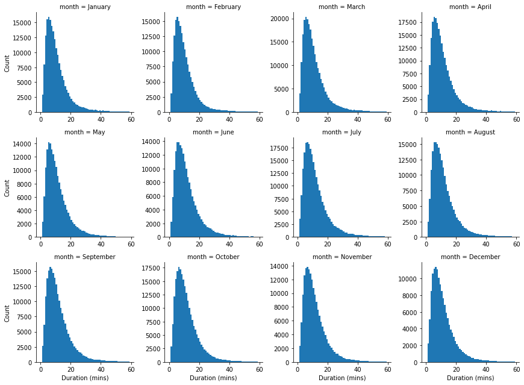

```python
#order = Baywheel_19_clean.groupby(Baywheel_19_clean.start_time.dt.month).mean().index
g = sb.FacetGrid(data = Baywheel_19_clean, col = 'month', col_wrap = 4, height = 3, sharey = False,sharex = False)
bins = np.arange(0,60,1)
g.map(plt.hist,"duration_min",bins = bins)
g.set_axis_labels("Duration (mins)", "Count");
```

#### trips duration distributions are the same for all the monthes except the peek of the distribution.

### Relation between trip duration and day of the week .

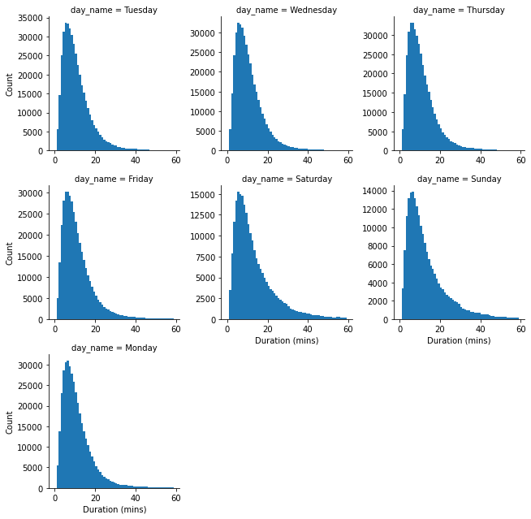

```python
plt.figure(figsize =(25,10))
g = sb.FacetGrid(data = Baywheel_19_clean, col = 'day_name', col_wrap = 3, height = 3, sharey = False,sharex = False)
bins = np.arange(0,60,1)
g.map(plt.hist,"duration_min",bins = bins)
g.set_axis_labels("Duration (mins)", "Count");
```

##### trips duration distributions are the same for all the days except the peek of the distribution.

### Relation between trip duration and user type .

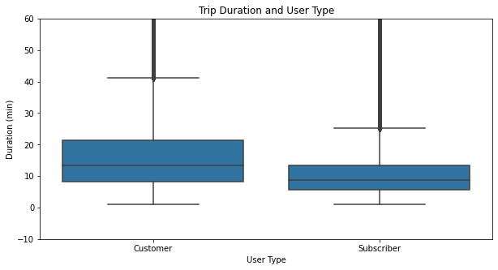

```python
plt.figure(figsize = [10, 5])
base_color = sb.color_palette()[0]
sb.boxplot(data = Baywheel_19_clean, x = 'user_type', y = 'duration_min', color = base_color)
plt.ylim([-10, 60])
plt.title('Trip Duration and User Type')
plt.xlabel('User Type')
plt.ylabel('Duration (min)');
```

#### customer rides longer trips then subscriber although number of subscriber riders are very high then customer.

### Relation between trip duration and rental_access_method

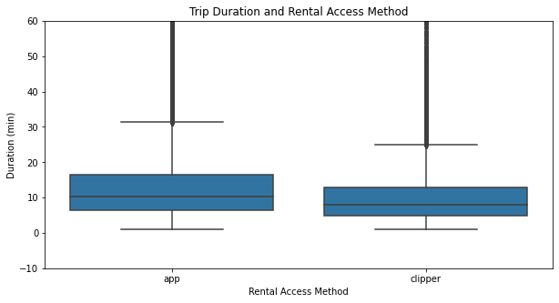

```python
plt.figure(figsize = [10, 5])
base_color = sb.color_palette()[0]
sb.boxplot(data = Baywheel_19_clean[Baywheel_19_clean.rental_access_method != 'None'], x = 'rental_access_method', y = 'duration_min', color = base_color)
plt.ylim([-10, 60])
plt.title('Trip Duration and Rental Access Method')
plt.xlabel('Rental Access Method')
plt.ylabel('Duration (min)');
```

#### we can see that users who use app for as a rental access method rides longer trips than users who use clipper

### Talk about some of the relationships you observed in this part of the investigation. How did the feature(s) of interest vary with other features in the dataset?

- The trips duration distribtuion is right skewed
- Tuseday is the day with the highest number of trips followed by Thursday . Sunday is is the day with the lowest number of trips.
- july is the month with the highest number of trips followed by March . December is the month the lowest number of trips .
- Hour 17 in the day is the hour with the highest number of trips followed by hour 8 and hour 18 . Hour 3 in the day is the lowest number of trips followed by hour 4 and hour 2.
- App is more likely to be used as a rental access method
- most of the users are subscribers .
- Almost trips duration distributions are the same for all the monthes except the peek of the distribution .
- Almost trips duration distributions are the same for all the days of the week except the peek of the distribution.
- customer rides longer trips then subscriber although number of subscriber riders are very high then customer.
- users who use app for as a rental access method rides longer trips than users who use clipper .

### Did you observe any interesting relationships between the other features (not the main feature(s) of interest)?

NO

## Multivariate Exploration

### Relation between trip duration , rental_access_method and user type features .

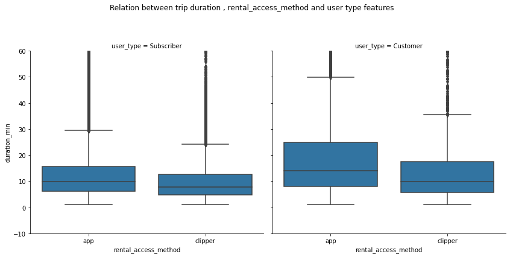

```python
g = sb.FacetGrid(data = Baywheel_19_clean[Baywheel_19_clean.rental_access_method != 'None'], col = 'user_type', height = 6)
g.map(sb.boxplot, 'rental_access_method', 'duration_min')
plt.ylim([-10, 60])
plt.subplots_adjust(top=0.8)
g.fig.suptitle('Relation between trip duration , rental_access_method and user type features');
```

### Were there any interesting or surprising interactions between features?

> I tought that subscribers who will ride for long times but it seems that custmors who ride longer time .